# Assignment: Data mining and statistical tests

Victor Salvat

01 octobre, 2025, 16:20

# 1 Correlations and linear regression

## 1.1 The problem

You want to know if there is a relationship between the nonuse of the proximal part of the upper limb (PANU) and the nonuse of the shoulder (SANU) or the elbow (EENU).

## 1.2 The data

Load data

```r
nonuse <- read.csv("data/test_data/NonUse.csv", sep = ",", header = TRUE)
head(nonuse)
```

|  | PANU | EENU | SANU |
| --- | --- | --- | --- |
| 1 | -1.91808 | 5.361647 | -4.838554 |
| 2 | 1.12289 | -2.505418 | 1.737964 |
| 3 | 1.84061 | 5.952974 | -1.442610 |
| 4 | 0.07064 | 4.038350 | -1.670562 |
| 5 | 3.15233 | NA | NA |
| 6 | 1.86301 | NA | NA |

```r
summary(nonuse)
```

```
##       PANU             EENU               SANU
##  Min.   :-3.306   Min.   :-33.9780   Min.   :-38.4178
##  1st Qu.: 1.629   1st Qu.: -0.4864   1st Qu.: -3.4968
##  Median : 4.370   Median :  6.2732   Median :  0.9708
##  Mean   : 9.742   Mean   :  8.3701   Mean   :  1.3908
##  3rd Qu.:13.919   3rd Qu.: 15.3383   3rd Qu.:  7.0470
##  Max.   :68.286   Max.   : 50.1748   Max.   : 40.1735
##  NA's   :13       NA's   :223        NA's   :223
```

This file contains measures of upper extremity non-use in stroke patients. The variables are:

```
PANU: Proximal Arm Non Use
SANU: Shoulder Antepulsion Non Use
EENU: Elbow Extension Non Use
```

In your notebook, make a clear description of the experiment, the variables and the data. Do not forget to give the units of each variable, and the range of possible values.

[output not shown]

## 1.3 Corelation analysis

Below are some questions to guide your analysis.

- *Is PANU correlated with SANU and/or EENU?*

```r
cor.test(nonuse$PANU, nonuse$EENU, method = "spearman")
```

```
##
##  Spearman's rank correlation rho
##
## data:  nonuse$PANU and nonuse$EENU
## S = 933144, p-value = 9.725e-09
## alternative hypothesis: true rho is not equal to 0
## sample estimates:
##       rho
## 0.3867028
```

```r
cor.test(nonuse$PANU, nonuse$SANU, method = "spearman")
```

```
##
##  Spearman's rank correlation rho
##
## data:  nonuse$PANU and nonuse$SANU
## S = 1192838, p-value = 0.001718
## alternative hypothesis: true rho is not equal to 0
## sample estimates:
##       rho
## 0.2160221
```

- *Visualize the PANU-SANU relationship (and the PANU-EENU relationship)*

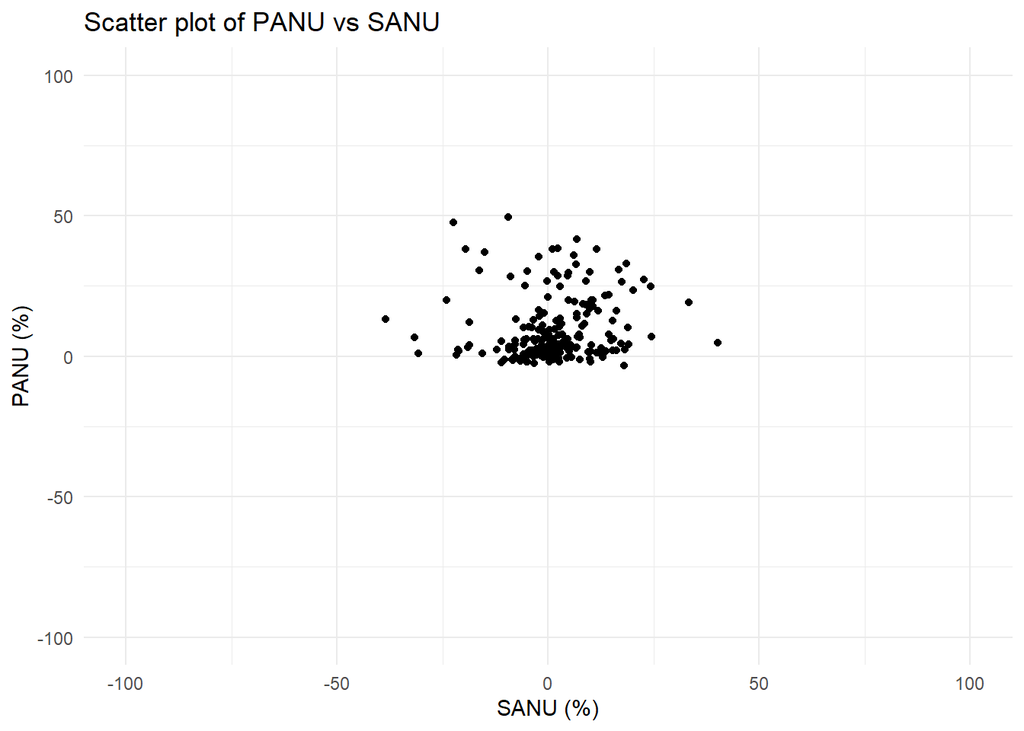

```r
library(ggplot2)
ggplot(nonuse, aes(x = SANU, y = PANU)) +
  geom_point() +
  xlim(-100, 100) +
  ylim(-100, 100) +
  labs(title = "Scatter plot of PANU vs SANU",
       x = "SANU (%)",
       y = "PANU (%)") +
  theme_minimal()
```

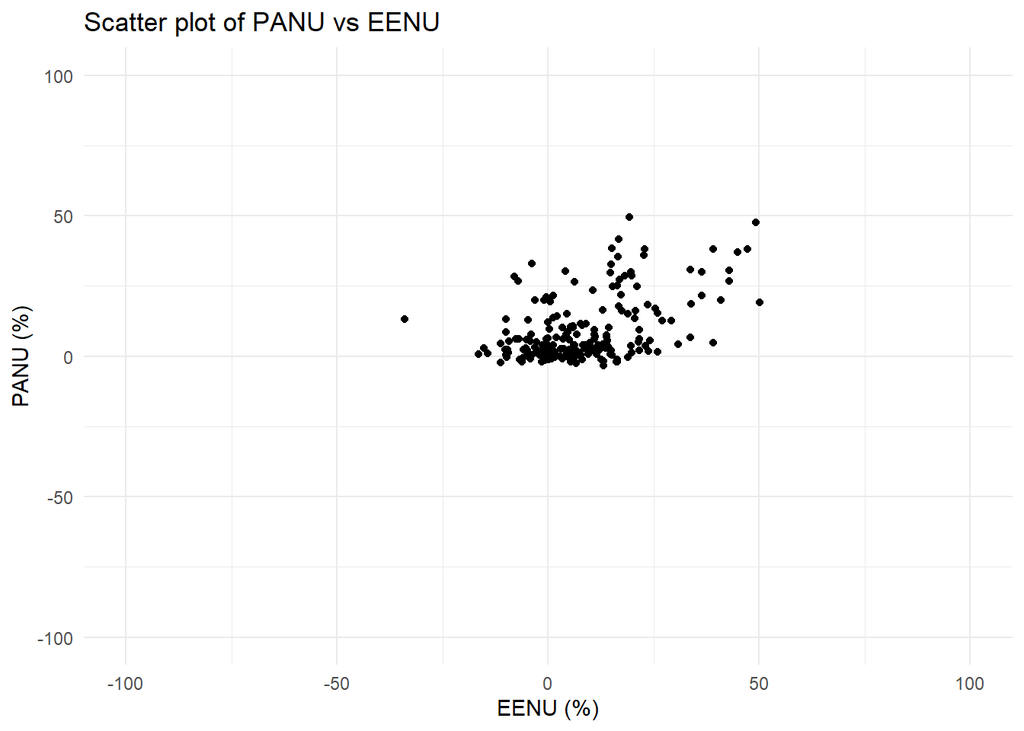

```r
library(ggplot2)
ggplot(nonuse, aes(x = EENU, y = PANU)) +
  geom_point() +
  xlim(-100, 100) +
  ylim(-100, 100) +
  labs(title = "Scatter plot of PANU vs EENU",
       x = "EENU (%)",
       y = "PANU (%)") +
  theme_minimal()
```

- *Perform a linear regression for PANU-SANU (and for PANU-EENU)*  
*We do not want to predict a linear relationship between PANU and SANU & EENU, but we do it because it is asked in the exercise…*

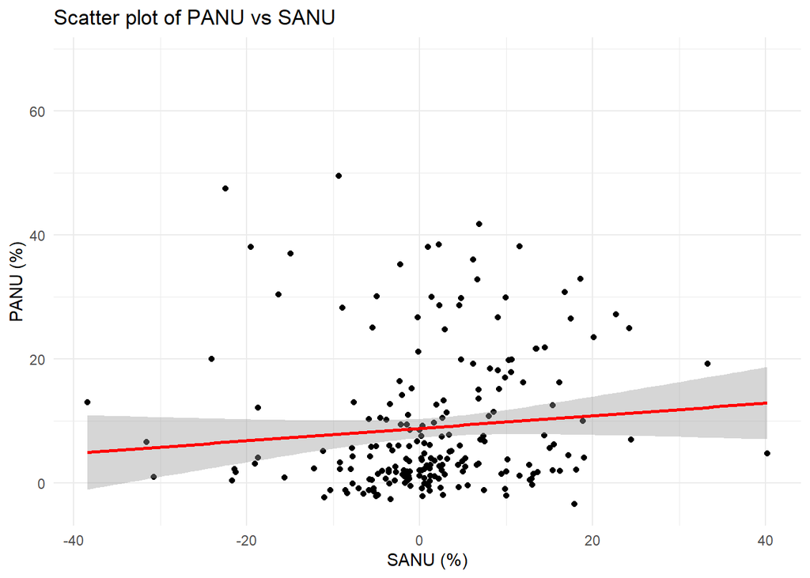

```r
library(ggplot2)
ggplot(nonuse, aes(x = SANU, y = PANU)) +
  geom_point() +
  geom_smooth(method = "lm", se = TRUE, color = "red") +
  labs(title = "Scatter plot of PANU vs SANU",
       x = "SANU (%)",
       y = "PANU (%)") +
  theme_minimal()
```

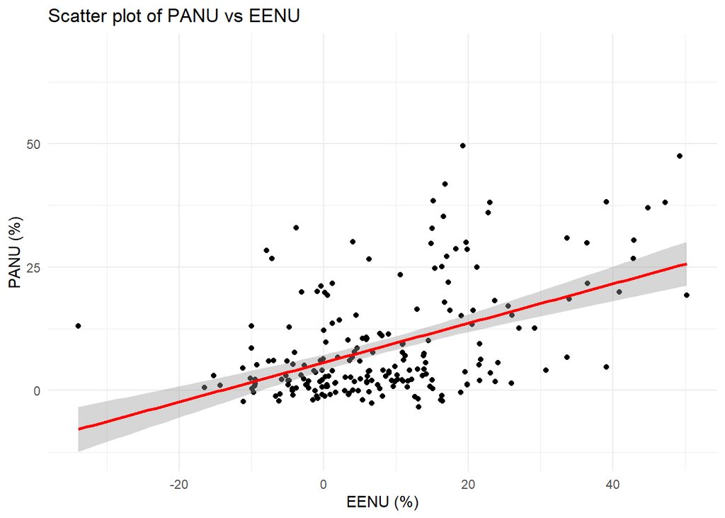

```r
library(ggplot2)
ggplot(nonuse, aes(x = EENU, y = PANU)) +
  geom_point() +
  geom_smooth(method = "lm", se = TRUE, color = "red") +
  labs(title = "Scatter plot of PANU vs EENU",
       x = "EENU (%)",
       y = "PANU (%)") +
  theme_minimal()
```

- *Give the regression equations: PANU = a* SANU + b and PANU = a * EENU + b*

```r
lm_sanu <- lm(SANU ~ PANU, data = nonuse)
summary(lm_sanu)
```

```
##
## Call:
## lm(formula = SANU ~ PANU, data = nonuse)
##
## Residuals:
##     Min      1Q  Median      3Q     Max
## -40.168  -4.593  -0.070   5.928  39.162
##
## Coefficients:
##             Estimate Std. Error t value Pr(>|t|)
## (Intercept)  0.58605    0.93615   0.626    0.532
## PANU         0.08933    0.06509   1.372    0.171
##
## Residual standard error: 10.55 on 207 degrees of freedom
##   (223 observations effacées parce que manquantes)
## Multiple R-squared:  0.009016,   Adjusted R-squared:  0.004229
## F-statistic: 1.883 on 1 and 207 DF,  p-value: 0.1714
```

```r
coef(lm_sanu)
```

```
## (Intercept)        PANU
##  0.58605205  0.08932839
```

```r
slope_sanu <- coef(lm_sanu)[2]
intercept_sanu <- coef(lm_sanu)[1]
cat("Regression equation: SANU =", slope_sanu, "* PANU +", intercept_sanu, "\n")
```

```
## Regression equation: SANU = 0.08932839 * PANU + 0.5860521
```

```r
lm_eenu <- lm(EENU ~ PANU, data = nonuse)
summary(lm_eenu)
```

```
##
## Call:
## lm(formula = EENU ~ PANU, data = nonuse)
##
## Residuals:
##     Min      1Q  Median      3Q     Max
## -44.622  -7.418  -1.214   6.620  36.023
##
## Coefficients:
##             Estimate Std. Error t value Pr(>|t|)
## (Intercept)  3.28370    1.04746   3.135  0.00197 **
## PANU         0.56462    0.07283   7.752    4e-13 ***
## ---
## Signif. codes:  0 '***' 0.001 '**' 0.01 '*' 0.05 '.' 0.1 ' ' 1
##
## Residual standard error: 11.8 on 207 degrees of freedom
##   (223 observations effacées parce que manquantes)
## Multiple R-squared:  0.225,  Adjusted R-squared:  0.2213
## F-statistic:  60.1 on 1 and 207 DF,  p-value: 4.005e-13
```

```r
coef(lm_eenu)
```

```
## (Intercept)        PANU
##   3.2836967   0.5646221
```

```r
slope_eenu <- coef(lm_eenu)[2]
intercept_eenu <- coef(lm_eenu)[1]
cat("Regression equation: EENU =", slope_eenu, "* PANU +", intercept_eenu, "\n")
```

```
## Regression equation: EENU = 0.5646221 * PANU + 3.283697
```

- *What are the limits of your analysis?*  
**Answer:** The analysis was constrained by substantial missing data in SANU and EENU, which reduced effective sample size and may have biased the results. The repeated-measures structure (eight observations per patient) was not fully accounted for in the correlation and simple regression models, potentially inflating significance levels. Moreover, Spearman’s rho captures monotonic but not strictly linear associations, limiting comparability with linear regression coefficients. Finally, the number of patients was not very large and there were some extreme values restricting the generalisability of the findings.

# 2 Statistical tests

In this series of exercises, you will explore how to compare two groups of data, using non-parametric tests or parametric tests.

## 2.1 Make clear what is a statistical test, and when to use it.

- *What is a median? A mean?*  
  The **median** is the middle value in a dataset when ordered from smallest to largest; it divides the data into two equal halves.  
  [Reference: Weiss, N. A. (2017). Introductory Statistics (10th ed.). Pearson]  
  The **mean** (or average) is the sum of all values divided by the number of observations; it represents the central tendency of a dataset.  
  [Reference: Moore, D. S., Notz, W. I., & Fligner, M. A. (2018). The Basic Practice of Statistics (8th ed.). W.H. Freeman]
- *What is a variance? A standard deviation?*  
  **Variance** measures the average squared deviation of each data point from the mean, indicating how spread out the values are in a dataset.  
  [Reference: De Veaux, R. D., Velleman, P. F., & Bock, D. E. (2016). Stats: Data and Models (4th ed.). Pearson]  
  **Standard deviation** is the square root of the variance, providing a measure of spread in the same units as the original data, and indicating how much individual data points typically deviate from the mean.  
  [Reference: De Veaux, R. D., Velleman, P. F., & Bock, D. E. (2016). Stats: Data and Models (4th ed.). Pearson]
- *What is a normal distribution?*  
  A **normal distribution** is a symmetric, bell-shaped probability distribution characterized by its mean and standard deviation, where most values cluster around the mean and probabilities taper off equally in both directions.  
  [Reference: Freedman, D., Pisani, R., & Purves, R. (2007). Statistics (4th ed.). W.W. Norton & Company]
- *What is a statistical test?*  
  A **statistical test** is a method used to make inferences or decisions about a population based on sample data, by evaluating hypotheses and determining the likelihood that observed differences or relationships occurred by chance. [Reference: Agresti, A., & Finlay, B. (2009). Statistical Methods for the Social Sciences (4th ed.). Pearson]
- *When to use a statistical test?*  
  **Statistical tests** are used when you want to compare groups, assess relationships between variables, or test hypotheses about population parameters based on sample data. They are appropriate when you have collected data and need to determine if observed patterns are statistically significant or likely due to random variation.  
  [Reference: Field, A. (2013). Discovering Statistics Using IBM SPSS Statistics (4th ed.). SAGE Publications]
- *What is a parametric test? A non-parametric test?*  
  **Parametric tests** are statistical tests that assume the data follows a specific distribution, typically a normal distribution, and rely on parameters such as the mean and standard deviation. Examples include t-tests and ANOVA.  
  [Reference: Zar, J. H. (2010). Biostatistical Analysis (5th ed.). Pearson]  
  **Non-parametric tests** do not assume a specific distribution and are used when data do not meet the assumptions required for parametric tests. They often rely on ranks or medians rather than means. Examples include the Mann-Whitney U test and the Kruskal-Wallis test.  
  [Reference: Conover, W. J. (1999). Practical Nonparametric Statistics (3rd ed.). Wiley]
- *What are the assumptions of parametric tests?*  
  **Parametric tests** typically assume:
1. The data are normally distributed.
2. Homogeneity of variance (equal variances across groups).
3. Independence of observations.
4. The data are measured at an interval or ratio scale.  
   [Reference: Field, A. (2013). Discovering Statistics Using IBM SPSS Statistics (4th ed.). SAGE Publications]
- *What are the assumptions of non-parametric tests?*  
  **Non-parametric tests** generally have fewer assumptions, but common ones include:
1. Independence of observations.
2. The data can be ordinal or continuous, but do not need to be normally distributed.
3. The samples are randomly drawn from the population.  
   [Reference: Conover, W. J. (1999). Practical Nonparametric Statistics (3rd ed.). Wiley]
- *What is a p-value?*  
  A **p-value** is the probability of obtaining test results at least as extreme as the observed results, assuming that the null hypothesis is true. It quantifies the evidence against the null hypothesis; a smaller p-value indicates stronger evidence to reject the null hypothesis.  
  [Reference: Agresti, A., & Finlay, B. (2009). Statistical Methods for the Social Sciences (4th ed.). Pearson]
- *What is the risk of error when using a statistical test?*  
  The **risk of error when using a statistical test** primarily refers to Type I and Type II errors. A Type I error occurs when the null hypothesis is incorrectly rejected (false positive), while a Type II error occurs when the null hypothesis is incorrectly accepted (false negative). The significance level (alpha) set for the test determines the acceptable risk of a Type I error, commonly set at 0.05.  
  [Reference: Field, A. (2013). Discovering Statistics Using IBM SPSS Statistics (4th ed.). SAGE Publications]
- *What is the difference between a paired and an unpaired test?*  
  A **paired test** is used when the same subjects are measured under two different conditions or at two different times, allowing for direct comparison of the paired observations. An example is the paired t-test.  
  [Reference: Zar, J. H. (2010). Biostatistical Analysis (5th ed.). Pearson]  
  An **unpaired test**, also known as an independent test, is used when comparing two independent groups of subjects, where the observations in one group do not influence those in the other. An example is the independent samples t-test.  
  [Reference: Field, A. (2013). Discovering Statistics Using IBM SPSS Statistics (4th ed.). SAGE Publications]

*The questions were answered using Co-Pilot and ClaudeAI (Sonnet 4.5)*

## 2.2 Effect of treatment over time

This is a very classical question in clinical or sport research: does a treatment-training have an effect over time?

To answer this question scientifically, measurements must be taken before and after treatment, and possibly later, in order to assess whether the effect is lasting or not.

### 2.2.1 The data

- Load the data “PrePost.csv”

```r
prepost <- read.csv("data/test_data/PrePost.csv", sep = ",", header = TRUE)
head(prepost)
```

|  | perf | time |
| --- | --- | --- |
| 1 | 125 | Before |
| 2 | 130 | Before |
| 3 | 132 | Before |
| 4 | 135 | Before |
| 5 | 136 | Before |
| 6 | 138 | Before |

```r
summary(prepost)
```

```
##       perf           time
##  Min.   :125.0   Length:16
##  1st Qu.:132.0   Class :character
##  Median :136.0   Mode  :character
##  Mean   :136.4
##  3rd Qu.:140.2
##  Max.   :148.0
```

*This file contains before/after measurements. The treatment is a rehabilitation training for individuals with cardiac conditions.*

The variables are:

```
Time: time of measurement (Pre or Post)<br>
Perf: performance score (higher is better)
```

Make a table, with one row per variable, and the following columns:

[output not shown]

### 2.2.2 The analysis

You want to know if the treatment has an effect on one or more of the measured variables.

- *Q: Does the treatment have an effect?*

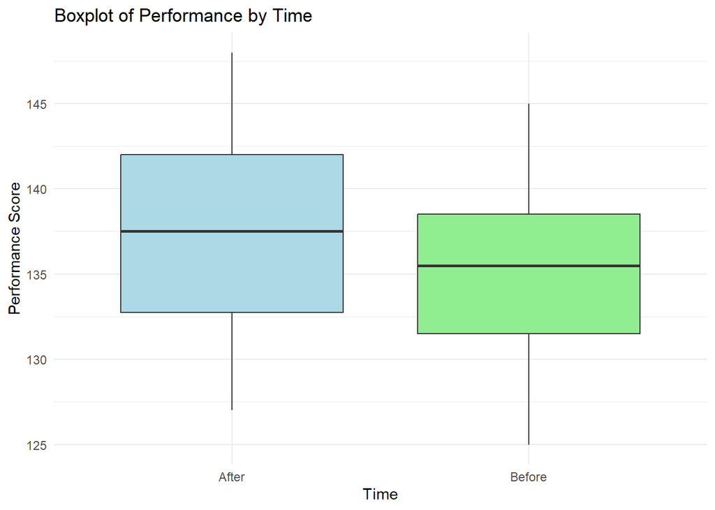

```r
library(ggplot2)
ggplot(prepost, aes(x = time, y = perf)) +
  geom_boxplot(fill = c("lightblue", "lightgreen")) +
  labs(title = "Boxplot of Performance by Time",
       x = "Time",
       y = "Performance Score") +
  theme_minimal()
```

**A:** The boxplot shows that performance scores are higher after rehabilitation compared to before, suggesting a positive treatment effect.

- *Q: What comparison are you going to make?*

**A:** Since the data consists of paired measurements (before and after treatment) on the same individuals, a *paired test* is appropriate.

- *Q: Which test will you use? Parametric or non-parametric?*

**A:** We check whether the differences are normally distributed. If they are, a paired t-test is appropriate; otherwise, the Wilcoxon signed-rank test should be used.

```r
# Prepare paired data
before <- prepost$perf[prepost$time == "Before"]
after  <- prepost$perf[prepost$time == "After"]

# Check normality of differences
shapiro.test(after - before)
```

```
##
##  Shapiro-Wilk normality test
##
## data:  after - before
## W = 0.89896, p-value = 0.2828
```

```r
# Parametric paired t-test
t.test(after, before, paired = TRUE)
```

```
##
##  Paired t-test
##
## data:  after and before
## t = 5.4006, df = 7, p-value = 0.001008
## alternative hypothesis: true mean difference is not equal to 0
## 95 percent confidence interval:
##  1.405392 3.594608
## sample estimates:
## mean difference
##             2.5
```

```r
# Non-parametric Wilcoxon signed-rank test
wilcox.test(after, before, paired = TRUE, exact = FALSE)
```

```
##
##  Wilcoxon signed rank test with continuity correction
##
## data:  after and before
## V = 36, p-value = 0.01356
## alternative hypothesis: true location shift is not equal to 0
```

**Interpretation:** Because the normality assumption was met, we used a paired t-test, which showed that performance increased significantly after treatment (mean difference = 2.5, p = 0.001).

- *Q: Which graph illustrates the effect of the treatment?*

**A:** The boxplot created earlier effectively illustrates the effect of the treatment by comparing performance scores before and after rehabilitation.

or

A paired line plot is more informative, as it shows each individual’s improvement.

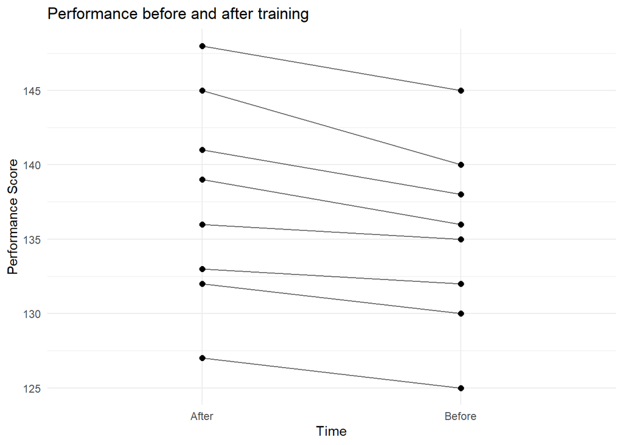

```r
# Add subject IDs for paired lines
prepost$subject <- rep(1:(nrow(prepost)/2), times = 2)

ggplot(prepost, aes(x = time, y = perf, group = subject)) +
  geom_line(alpha = 0.6) +
  geom_point(size = 2) +
  theme_minimal() +
  labs(title = "Performance before and after training",
       x = "Time",
       y = "Performance Score")
```

**Interpretation:** The paired line plot clearly shows that nearly all subjects improved after rehabilitation.

- *Q: Write sentence in your thesis to explain your result*

## 2.3 Testing some stereotypes

Humans have stereotypes, some of them are probably true, some others are probably false.

### 2.3.1 The data

Download the file “snore.txt”

This file contains anthropometric and qualitative measurements (1 person per line).

- Load the data:

```r
snore <- read.table("data/test_data/snore.txt", sep = "\t", header = TRUE)

# Rename variables for consistency
names(snore) <- c("age","weight","height","alcohol","sex","snore","smoke")

# Recode factors
snore$sex    <- factor(snore$sex, levels = c("H","F"), labels = c("Male","Female"))
snore$snore  <- factor(snore$snore, levels = c("N","O"), labels = c("No","Yes"))
snore$smoke  <- factor(snore$smoke, levels = c("N","O"), labels = c("No","Yes"))
snore$alcohol <- as.numeric(snore$alcohol)  # number of drinks/week
head(snore)
```

|  | age | weight | height | alcohol | sex | snore | smoke |
| --- | --- | --- | --- | --- | --- | --- | --- |
| 1 | 47 | 71 | 158 | 0 | Male | No | Yes |
| 2 | 56 | 58 | 164 | 7 | Male | Yes | No |
| 3 | 46 | 116 | 208 | 3 | Male | No | Yes |
| 4 | 70 | 96 | 186 | 3 | Male | No | Yes |
| 5 | 51 | 91 | 195 | 2 | Male | Yes | Yes |
| 6 | 46 | 98 | 188 | 0 | Female | No | No |

```r
summary(snore)
```

```
##       age            weight           height         alcohol          sex
##  Min.   :23.00   Min.   : 42.00   Min.   :158.0   Min.   : 0.00   Male  :75
##  1st Qu.:43.00   1st Qu.: 77.00   1st Qu.:166.0   1st Qu.: 0.00   Female:25
##  Median :52.00   Median : 95.00   Median :186.0   Median : 2.00
##  Mean   :52.27   Mean   : 90.41   Mean   :181.1   Mean   : 2.95
##  3rd Qu.:62.25   3rd Qu.:107.00   3rd Qu.:194.0   3rd Qu.: 4.25
##  Max.   :74.00   Max.   :120.00   Max.   :208.0   Max.   :15.00
##  snore    smoke
##  No :65   No :36
##  Yes:35   Yes:64
##
##
##
##
```

The variables are:

Make a table, with one row per variable, and the following columns:

| Variable | Description | Unit | Possible values |
| --- | --- | --- | --- |
| sex | Biological sex | N/A | Categorical: “Male”, “Female” |
| height | Height of the individual | cm | Positive numeric values |
| weight | Weight of the individual | kg | Positive numeric values |
| age | Age of the individual | years | Positive numeric values |
| snore | Snoring status | N/A | Categorical: Yes, No |
| alcohol | Alcohol consumption | units/week | integer ≥ 0 |
| smoke | Smoking status | N/A | Categorical: Yes, No |

### 2.3.2 The analysis

Do the data confirm the following stereotypes? Provide a reasoned answer (data, figure, result sentence) for each question.

- *Q1: Are snorers fatter?*

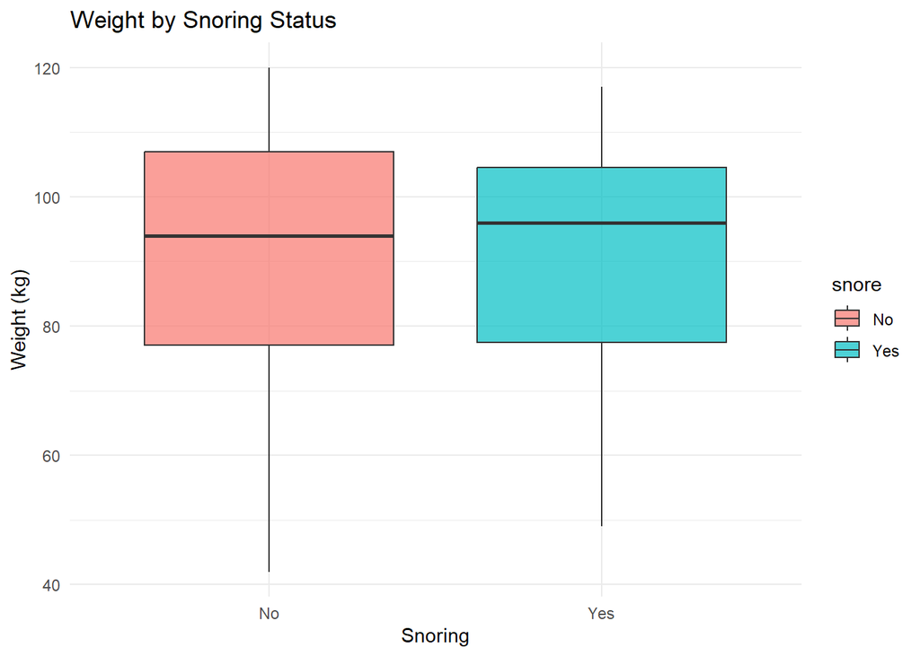

```r
library(ggplot2)
ggplot(snore, aes(x = snore, y = weight, fill = snore)) +
  geom_boxplot(alpha = 0.7) +
  labs(title = "Weight by Snoring Status", x = "Snoring", y = "Weight (kg)") +
  theme_minimal()
```

```r
# Test difference
t.test(weight ~ snore, data = snore)
```

```
##
##  Welch Two Sample t-test
##
## data:  weight by snore
## t = 0.048906, df = 71.7, p-value = 0.9611
## alternative hypothesis: true difference in means between group No and group Yes is not equal to 0
## 95 percent confidence interval:
##  -7.603312  7.985729
## sample estimates:
##  mean in group No mean in group Yes
##          90.47692          90.28571
```

- *Q2: Do snorers drink or smoke more?*

```r
library(dplyr)
library(tidyr)

# Smoking vs Snoring
tab_smoke <- table(snore$snore, snore$smoke)
chisq.test(tab_smoke)
```

```
##
##  Pearson's Chi-squared test with Yates' continuity correction
##
## data:  tab_smoke
## X-squared = 0.68872, df = 1, p-value = 0.4066
```

```r
# Alcohol vs Snoring
t.test(alcohol ~ snore, data = snore)
```

```
##
##  Welch Two Sample t-test
##
## data:  alcohol by snore
## t = -2.3473, df = 64.789, p-value = 0.02197
## alternative hypothesis: true difference in means between group No and group Yes is not equal to 0
## 95 percent confidence interval:
##  -3.0712171 -0.2474642
## sample estimates:
##  mean in group No mean in group Yes
##          2.369231          4.028571
```

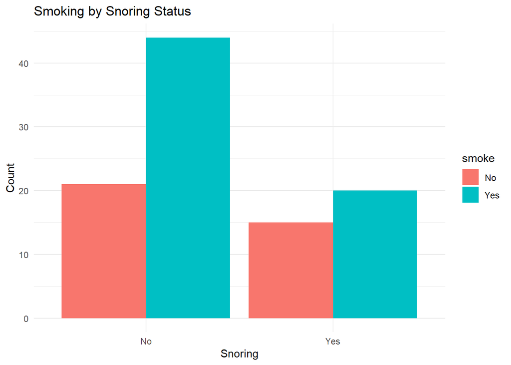

```r
# Plots
snore %>%
  group_by(snore, smoke) %>%
  summarise(count = n(), .groups="drop") %>%
  ggplot(aes(x = snore, y = count, fill = smoke)) +
  geom_bar(stat="identity", position="dodge") +
  labs(title = "Smoking by Snoring Status", x = "Snoring", y = "Count") +
  theme_minimal()
```

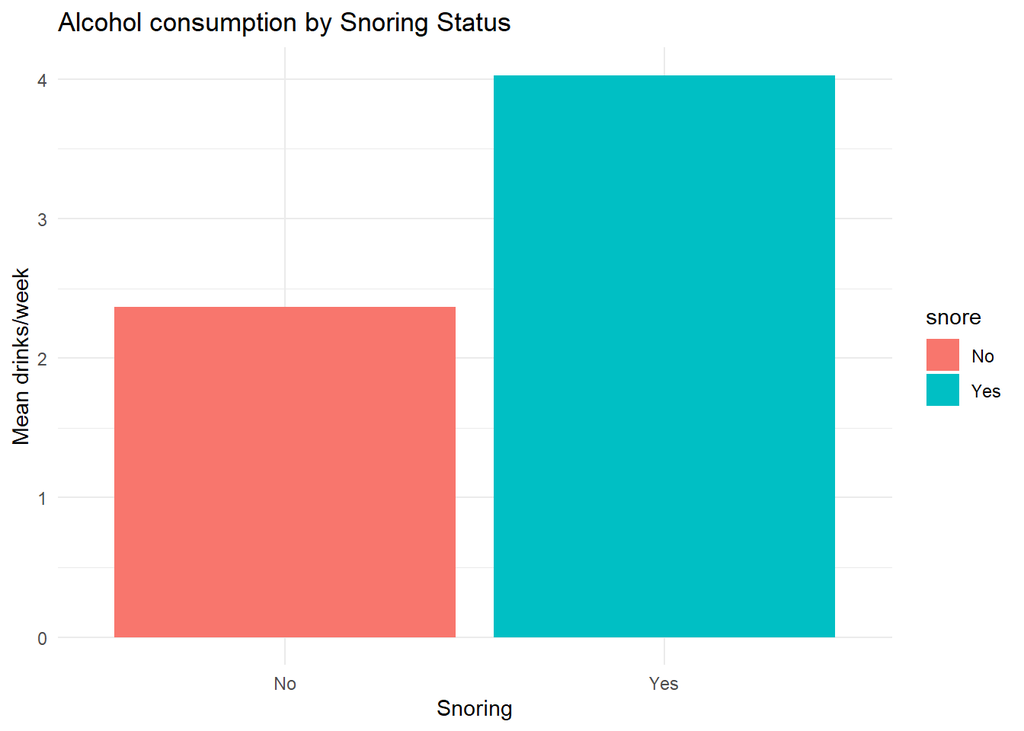

```r
snore %>%
  group_by(snore) %>%
  summarise(mean_alcohol = mean(alcohol), .groups="drop") %>%
  ggplot(aes(x = snore, y = mean_alcohol, fill = snore)) +
  geom_col() +
  labs(title = "Alcohol consumption by Snoring Status", x = "Snoring", y = "Mean drinks/week") +
  theme_minimal()
```

- *Q3: Are men fatter?*

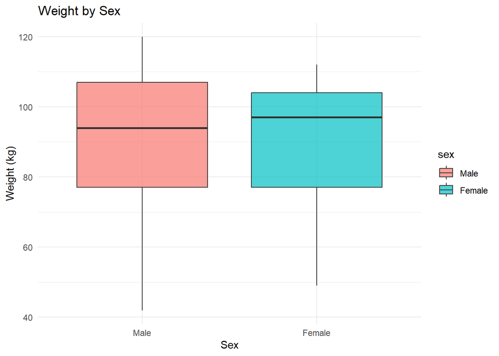

```r
ggplot(snore, aes(x = sex, y = weight, fill = sex)) +
  geom_boxplot(alpha = 0.7) +
  labs(title = "Weight by Sex", x = "Sex", y = "Weight (kg)") +
  theme_minimal()
```

```r
t.test(weight ~ sex, data = snore)
```

```
##
##  Welch Two Sample t-test
##
## data:  weight by sex
## t = 0.34318, df = 43.104, p-value = 0.7331
## alternative hypothesis: true difference in means between group Male and group Female is not equal to 0
## 95 percent confidence interval:
##  -7.086591  9.993258
## sample estimates:
##   mean in group Male mean in group Female
##             90.77333             89.32000
```

- *Q4: Do women smoke less?*

```r
tab_gender_smoke <- table(snore$sex, snore$smoke)
chisq.test(tab_gender_smoke)
```

```
##
##  Pearson's Chi-squared test with Yates' continuity correction
##
## data:  tab_gender_smoke
## X-squared = 7.0023, df = 1, p-value = 0.00814
```

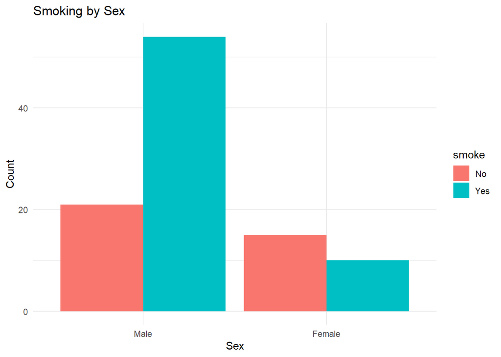

```r
# Barplot
snore %>%
  group_by(sex, smoke) %>%
  summarise(count = n(), .groups="drop") %>%
  ggplot(aes(x = sex, y = count, fill = smoke)) +
  geom_bar(stat="identity", position="dodge") +
  labs(title = "Smoking by Sex", x = "Sex", y = "Count") +
  theme_minimal()
```

**A4:** The bar plot shows that the proportion of smokers is lower among women compared to men. The chi-squared test confirms that this association is statistically significant (p < 0.05), indicating that women do indeed smoke less than men.

- *From a more general perspective: Are there any correlations between variables?*

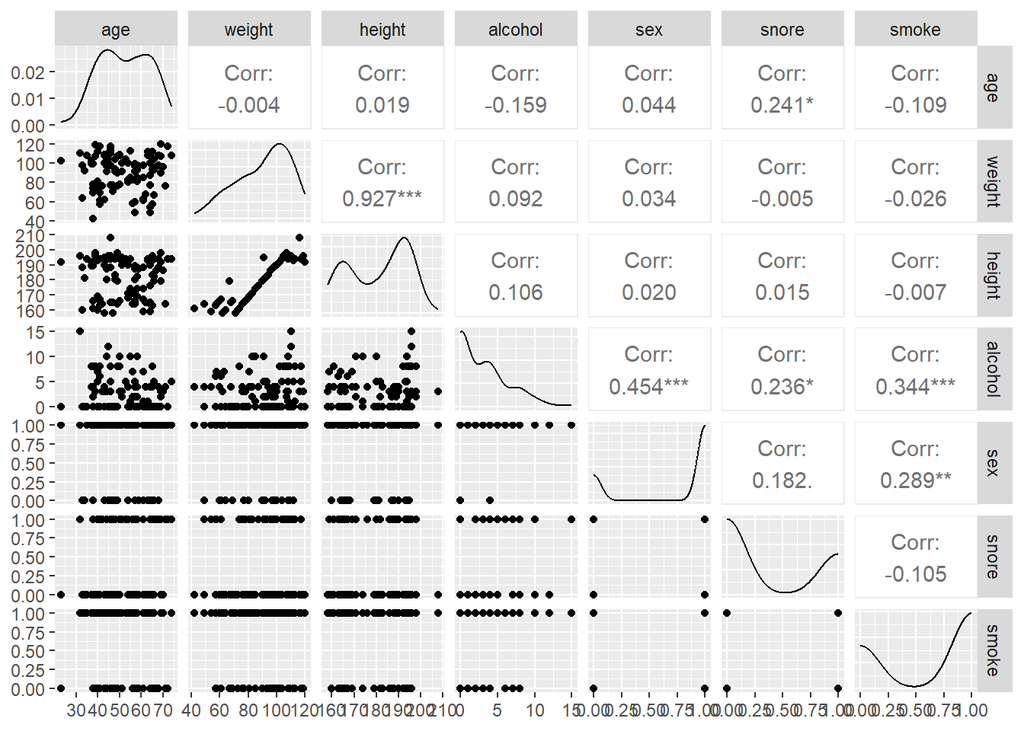

```r
library(GGally)
snore_numeric <- snore %>%
  mutate(
    sex = ifelse(sex=="Male",1,0),
    snore = ifelse(snore=="Yes",1,0),
    smoke = ifelse(smoke=="Yes",1,0)
  )
ggpairs(snore_numeric[,c("age","weight","height","alcohol","sex","snore","smoke")])
```

# 3 Epilogue: beyond the scope of this series

Finally, some of you may want to go beyond the scope of this series with new questions, such as:

- *Q1: Can you predict the value of one variable from the others? (linear regression, logistic regression, etc.)*

**A:** Yes, logistic regression can be used to predict the likelihood of snoring based on variables such as weight, age, sex, smoking status, and alcohol consumption. This model can help identify key predictors of snoring.

- *Q2: Can you classify individuals based on their variables? (clustering, PCA, etc.)*

**A:** Yes, clustering techniques like k-means or hierarchical clustering can be applied to group individuals based on similarities in their anthropometric and lifestyle variables. Principal Component Analysis (PCA) can also be used to reduce dimensionality and identify patterns in the data.

*Copilot, ClaudeAI (Sonnet 4.5) and ChatGPT were used to generate parts of the code and text in this notebook.*

*Time spent: ~6 hours*